# Results

[output not shown]

## 1 Key points of literature

- HA has two widely accepted forms - LMM and HMM. LMW is pro inflammatory, while HMM is antiinflammatory. HMM also seems to enhance regeneration. HMM forms the crosslinks within ECM which makes the ECM soft. HMM also has a higher hydration capacity which enhances the ECM softness.
- Free HMM in solution gets endocytosed and gets degraded into LMM. So the disruption of ECM upon wound releasing HMM HA into the solution could lead to degradation of HA and induction of an inflammatory reaction. If Inflammation enhances EMT, ZEB1 can induce the production of HA (and collagen?), leading to forming soft ECM. If HA is not produced/not crosslinked within ECM, you get fibrosis. For this theory to work, we need the following elements
  - Wounds should have fibroblasts that are ready to take over
  - How does LMM induce inflammation? They are not cytokines.
  - Inflammation should induce EMT
  - EMT induction should enhance the production of collagen, HA and other crosslinkers needed for soft ECM formation. (Which is a point of contest because EMT seems to induce the formation of stiff ECM with high elastic modulus. Need to figure out where these things differ)
  - How does MET happen?

### 1.1 HA turnover

HA turnover rates are high. There is a constant production and degradation happening.

- Degradation via membrane proteins like HYALs and TMEM2 extracellularly
  - TMEM2 based degradation has been shown to release TGFß stored in ECM extracellularly, which in turn leads to mitochondria remodelling and immune system activation [paper](https://www.sciencedirect.com/science/article/pii/S009286742400638X?via%3Dihub)
- Endocytosis followed by either storage or degradation by CD44

### 1.2 Effect of HA on proliferation/remodelling

HA rich ECM could be important for supporting the sustanence of stemlike behavior. YAP/TAZ nuclear localization has been argued to be a crucial step in both proliferation and differentiation, though there are context dependendent variablilities. Various biomechanical studies together suggest that addition of HA to a collagen matrix can lead to reduction in cell spreading, which in turn can lead to closing of nuclear pore complexes, reducing YAP/TAZ localization. A biochemical pathway that supports this route is the [sequestration of PAR1b by clustered CD44 that interacts with HMM HA](https://www.sciencedirect.com/science/article/pii/S1534580719302990?via%3Dihub). When HMM HA is degraded, PAR1b is released, reducing YAP phosphorylation via the HIPPO pathway and allowing YAP nuclear localization. However, this HA dependent biochemical mechanism is less generalizable than the biomechanical mechanism, particularly because not all tissues have HA rich ECM. Could it explain the strict differentiated state of neural cells? Brain does have astrocytes. Another potential biochemical pathway is CD44- RhoA- F actin polymerization leading to YAP/TAZ localization.

### 1.3 YAP TAZ

YAP TAZ seems to be very important for various processes crucial for wound healing, such as proliferation, differentiation, etc. It is also the primary effector of mechanotransduction in cells.

## 2 References for links

- ZEB activates HAS2
- HA activates CD44
- CD44 inhibits HA through internalization
- TGFb1 signalling activates HAPLN1
- HAPLN1 crosslinks HA and collagen
- HAPLN1 and TGFb regulate collagen deposition
- EMT-stemness interactions
- EMT-proliferation interactions
- HYAL1 gets activated by TGFb1 signalling
- YAP1/TAZ pathway increases RHAMM expression, which in turn increases HA dependent migration : [paper](https://pmc.ncbi.nlm.nih.gov/articles/PMC5706831/)
- HA is necessary for YAP/TAZ nuclear localization in zebrafish fin regeneration, which in turn is necessary for proliferation, as measured by perturbation experiments : [paper](https://www.biorxiv.org/content/10.1101/2024.11.15.623835v1.full)
- HMM HA leads to CD44 clustering, clustered CD44 sequesters PAR1b. PAR1b unsequestered can sequeuster MST1 and LATS1, kinases in Hippo pathway. Hippo pathway stops YAP/TAZ localization, which is indirectly supported by the presence of HMM HA. LMM HA has the opposite function. [paper](https://www.sciencedirect.com/science/article/pii/S1534580719302990?via%3Dihub#fig1)
- CD44 - RhoA - Factin polymerization - YAP TAZ localization pathway

## 3 Process

wound -> free HA -> fibroblasts degrading the HA -> LMM HA inducing inflammation and stemness in fibroblasts -> inflammation inducing EMT -> wound closure, HA production, collagen production -> A soft ECM with stem cells that can reform the epithelium

## 4 Network and simulations

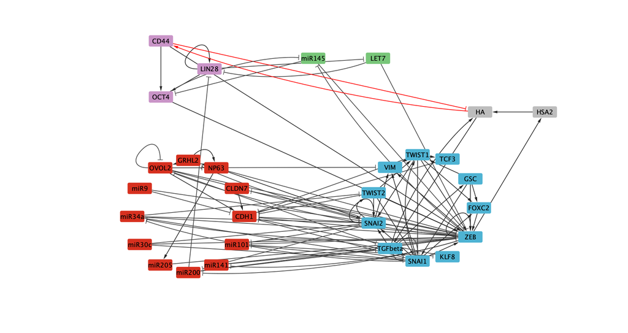

EMT-Stemness-HA Network

Note that there is a negative feedback involving HA via CD44 (highlighted in red) that represents the internalizaion of *free* HA by CD44 and subsequent degradation. This feedback is crucial in this network to obtain the right stemness properties. We currently do not distinguish between free HA and HA bound to the ECM. That distinction could be made when including ECM components.

## 5 Results

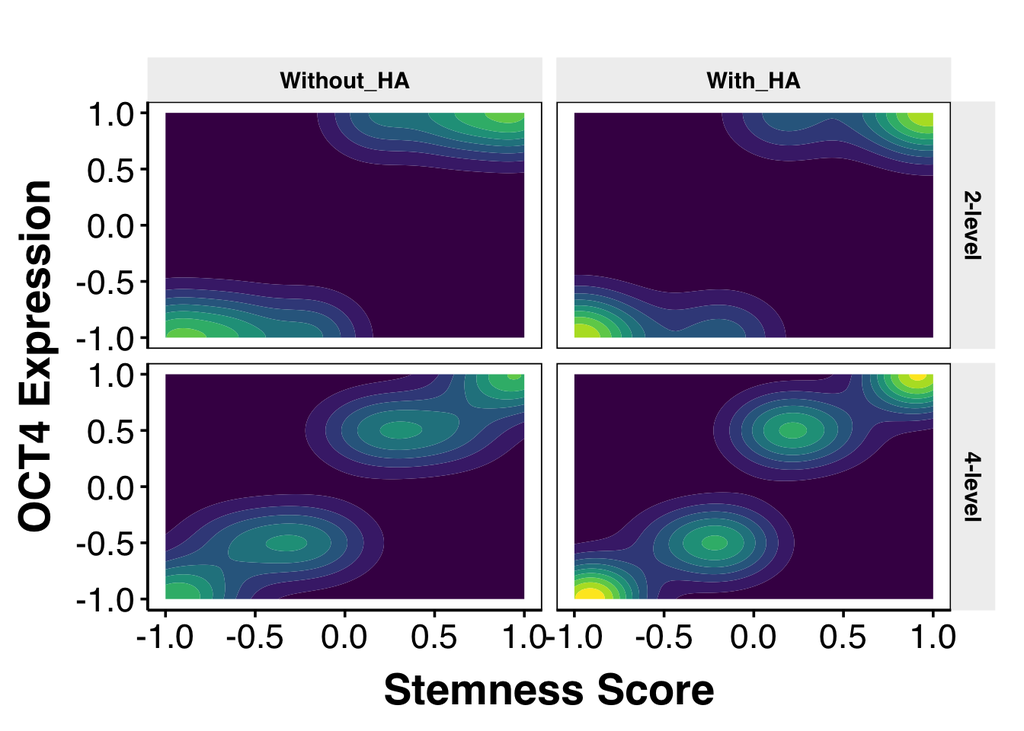

In 2-level formalism intermediate expression levels are not allowed, but it is clearly seen in 4-level formalism that as stemness score approaches zero (intermediate score), we see intermediate levels of OCT4 expression. Thus, near zero stemness score is desirable.

Comparing the steady state frequencies in different regions of EMTscore-stemness score space.

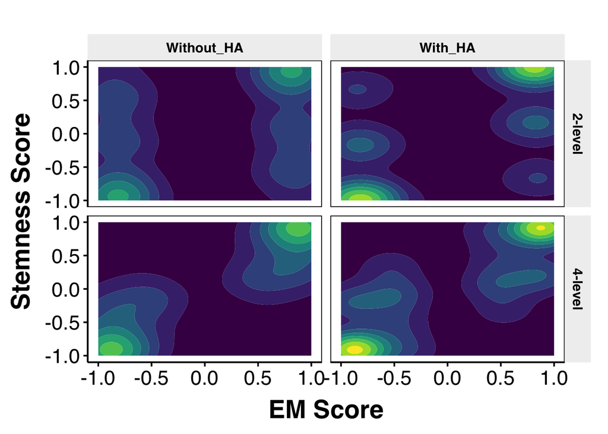

There is a clear increase in stability of states with intermediate stemness score upon adding HA related interactions to the network. However, that does not reflect as cleanly in OCT4 expression.

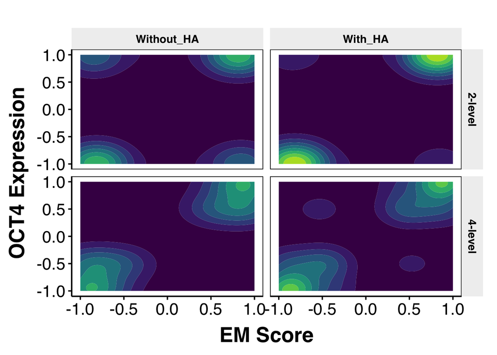

## 6 Further modelling plans

Wound healing requires the following major components - Cellular processes that include Inflammation, cell migration, stemness, ECM manipulation and proliferation. Companion to all this is EMT - Cellular components that include fibroblasts, keratinocytes, immune cells, endothelial cells and platelets - Environmental factors include HA, Collagen, crosslinker proteins and glycans, Eschar (comprised of blood clot) and cytokines - Stages include - Pre Wound: - Pre wound concentration of cytokines and growth factors, and immune cells available on site that can trigger immediate inflammation upon wound formation - Keratinocytes in epidermis and the Basal stem cells (melanocytes?) that maintain a homeostasis of epidermis thickness and composition. During wound, this layer would blow away entirely. Outside the wound radius, the stem cells might be useful once the dermis is filled. - Keratinocytes and fibroblasts Dermal layer consists of keratinocytes, fibroblasts, immune cells, and various other things. - Other layers exist (such as the subcutaneous fat pad), but they would probably require deeper wounds to be under consideration? - Right after the wound: - - Post wound recruitment of immune cells that triggers inflammation positive feedback loops - Migration and remodelling of keratinocytes - proliferation

## 7 Next Steps

- Current model treats the HA as unbound to ECM, except maybe for the activation of TGFß. How to include HA ECM dynamics?
- Inlcude the ECM effects:
  - https://pmc.ncbi.nlm.nih.gov/articles/PMC4452027/
  - https://pmc.ncbi.nlm.nih.gov/articles/PMC8037024/

## 9 Pontential sources of complete regeneration data

- Axolotl limb regeneration
- Zebra fish fin regeneration
- MRL mouse regeneration
- Humal oral wound healing
- MRL mouse ear hole regeneration
- Mouse fetal skin

## 10 References for links

- ZEB activates HAS2
- HA activates CD44
- CD44 inhibits HA through internalization - CD44 + HYAL2 internalize and degrade HA. [paper](https://www.sciencedirect.com/science/article/pii/S002192582068855X)
- TGFb1 signalling activates HAPLN1
- HAPLN1 crosslinks HA and collagen
- HAPLN1 and TGFb regulate collagen deposition
- EMT-stemness interactions
- EMT-proliferation interactions
- HYAL1 gets activated by TGFb1 signalling
- YAP1/TAZ pathway increases RHAMM expression, which in turn increases HA dependent migration : [paper](https://pmc.ncbi.nlm.nih.gov/articles/PMC5706831/)
- HA is necessary for YAP/TAZ nuclear localization in zebrafish fin regeneration, which in turn is necessary for proliferation, as measured by perturbation experiments : [paper](https://www.biorxiv.org/content/10.1101/2024.11.15.623835v1.full)
- HMM HA leads to CD44 clustering, clustered CD44 sequesters PAR1b. PAR1b unsequestered can sequeuster MST1 and LATS1, kinases in Hippo pathway. Hippo pathway stops YAP/TAZ localization, which is indirectly supported by the presence of HMM HA. LMM HA has the opposite function. [paper](https://www.sciencedirect.com/science/article/pii/S1534580719302990?via%3Dihub#fig1)
- CD44 - RhoA - Factin polymerization - YAP TAZ localization pathway
- STAT3 activates HAS2 in keratinocytes. paper Also valid in fibroblasts. [paper1](https://link.springer.com/article/10.1007/s00418-012-1000-x), [paper2](https://www.mdpi.com/1422-0067/22/4/2057)
- TGFb1 - HAS2 - STAT3 pathway connection [thesis](https://www.proquest.com/docview/2441570502?%20Theses&fromopenview=true&pq-origsite=gscholar&sourcetype=Dissertations%20)
- CD44 mediated CIP in naked mole rats - [paper](https://www.nature.com/articles/nature12234)
- CD44 - NF2 (aka merlin) - inhibition of proliferation mechanism - [paper] (https://onlinelibrary.wiley.com/doi/full/10.1002/ijc.33144). In absence of NF2, CD44 seems to enhance proliferation [paper](https://onlinelibrary.wiley.com/doi/full/10.1002/ijc.33144). NF2 inhibits proliferation by activating the HIPPO pathway ()
- NF2 activity
- CD44 upregulates iron intake via HMM HA. (why not LMM HA? - probably because of the lack of endocytosis). CD44 mediated endocytosis reduces TFR1 mediated iron intake. The CD44 pathway gets stronger with EMT, which also increases the expression of iron induced demethylase PHF8, which in turn reduces the H3K9me2 marking on CD44. [paper](https://www.nature.com/articles/s41557-020-0513-5). Is CD44 or some other pathway important in activating PHF8 along with iron? Why is it not active in epithelial state?

## 11 Supporting statements and citations for the importance of HA in wound regeneration

- Fetal fibroblasts form HA rich ECMs, which adult fibroblasts do not. IL10 is a key molecule seen in fetal wounds but not in adult wounds, and there is evidence that IL10 can induce HA production in fibroblasts. [paper](https://faseb.onlinelibrary.wiley.com/doi/full/10.1096/fj.201600856R). IL10->STAT3->HAS2->HA
- [Hyaluronan turnover by keratinocytes](https://pmc.ncbi.nlm.nih.gov/articles/PMC11292368/),
- HA - CD44 based cell migration via CD44 coated protrusions, observed in glioblastoma

## 12 Misc ::: notes

- Measuring ECM - matrisome score
- Measuring HA expression - ratio of HAS to HYAL
- Measuring proliferation - Proliferative Cell Nuclear Antigen

## 13 Interesting tidbits about HA that may not mean anything rn

- Increased HA production in rats (induced by naked mole rat HAS2) enhances mouse lifespan [paper](https://www.nature.com/articles/s41586-023-06463-0).
- HA can confer resistence to doxirubicin by binding to it. [paper](https://www.nature.com/articles/s41388-023-02837-w?fromPaywallRec=false)
- HA is essential to “cold-induced adipocyte beiging” - turning white adipocytes to beige/brown adipocytes that are more metabolically active. [paper](https://www.mdpi.com/2073-4409/13/15/1233). In the same line, HA being a product of glucose metabolism, was believed to be overexpressed in diabetes because of the increase in plasma hyaluranon, with the inhibitor proposed as a treatment. But turns out it is exactly the opposite in adipocytes. [paper] (https://www.nature.com/articles/s41467-021-25025-4)